# CSF_Spectronaut_protein_swap data visualization

Explicit protein-swap benchmark data

This vignette uses the same structure as the CSF sample-swap data-visualization vignettes, but it describes the explicit protein-swap benchmark. In this dataset, the Positive class is created by swapping matched proteins rather than by swapping sample labels. The `good_data` subset uses neat samples only, so the Positive/Negative labels come from the protein-pair construction and not from dilution-level sample swapping.

All quantitative panels in this document read `CSF_Spectronaut_protein_swap/good_data/Report.tsv` directly. Intensities come from `FG.Quantity`, are transformed with `log2`, deduplicated at `(run, protein, precursor)`, and then averaged to one protein-level value per run before fold changes and SDs are computed. No MSstats RDA object is used in this vignette.

# Truth-file consistency

The canonical protein-swap truth list is `CSF_protein_swap_list.csv`. The pair-construction table is `Report_swap_ground_truth.tsv`; it contains one row per matched protein pair and records the expected pair-level log2 fold change. The table below checks that the canonical Positive proteins are exactly the proteins represented by the pair table.

Consistency check between the canonical protein-swap truth list and the protein-pair table used to generate the explicit report.

| check | value |
| --- | --- |
| canonical truth rows | 2244 |
| canonical Positive proteins | 224 |
| canonical Negative proteins | 2020 |
| protein-pair rows | 112 |
| unique pair-table Positive proteins | 224 |
| canonical Positives missing from pair table | 0 |
| pair-table proteins missing from canonical Positives | 0 |

# Acquisition schedule

This figure shows the Good-run subset used for the protein-swap benchmark. The points are runs from `CSF_Spectronaut_protein_swap/good_data/annotation.csv`. In this dataset the data modification is at the protein level, not at the run-label level, so no sample-pair curves are shown. The plotted data later are read from `CSF_Spectronaut_protein_swap/good_data/Report.tsv`.

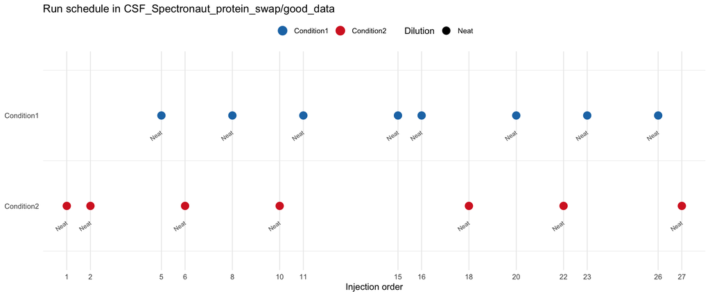

# Heatmap of the explicit protein-swap file

This heatmap uses direct report-derived protein/run intensities. For each run, precursor-level `FG.Quantity` values are log2-transformed and averaged to one value per protein. Rows are proteins from the current protein-swap truth list; columns are Good runs. Values are row-z-scored within protein. Positive proteins are the protein-pair members and should carry the constructed signal; Negative proteins should remain near the null.

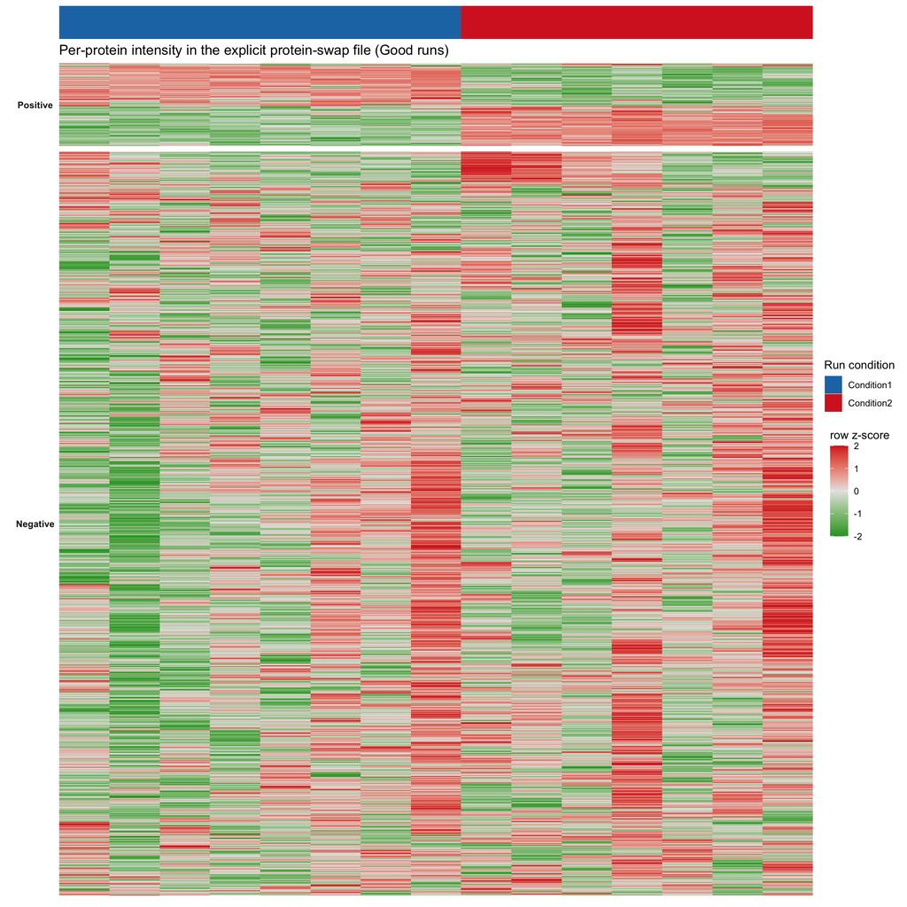

# Per-protein effect size and within-condition variance

The following panels summarize the same direct report-derived protein/run matrix. The effect size is mean log2 intensity in Condition1 minus Condition2. The pooled SD is computed from within-condition SDs across runs. Unlike the sample-swap benchmark, this design should not make the Negative class a within-condition mixture of Neat and 1:2 samples; `good_data` contains neat samples only.

Effect-size and pooled within-condition SD summary for the explicit protein-swap good_data report.

| class | proteins | median_fc | mean_fc | median_sd | mean_sd | q25_sd | q75_sd |
| --- | --- | --- | --- | --- | --- | --- | --- |
| Negative | 2019 | -0.073 | -0.098 | 0.325 | 0.426 | 0.224 | 0.517 |
| Positive | 224 | -0.339 | -0.149 | 0.624 | 0.683 | 0.457 | 0.869 |

## Effect size

This density plot checks the protein-swap signal. Negative proteins should be centered closer to zero. Positive proteins are matched protein-pair members, so their effect-size distribution reflects the constructed protein-pair signal rather than a sample dilution effect.

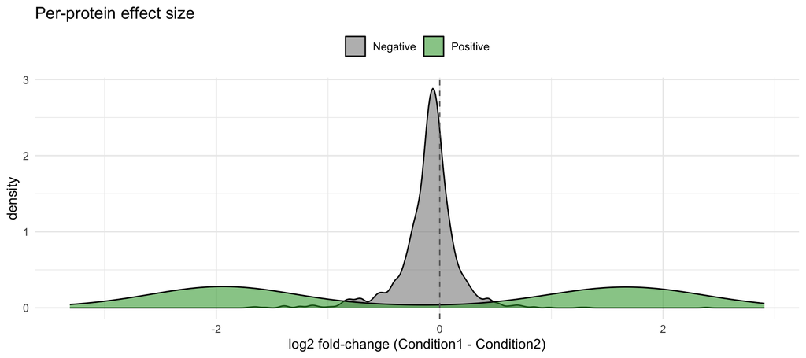

## Within-condition standard deviation

This density plot checks whether the protein-swap benchmark avoids the sample-swap variance artifact. Because `good_data` contains neat samples only, Negative proteins should not acquire the same within-condition dilution-mixture variance that appears in the sample-swap benchmark.

The pattern shown here is the expected direction for regulated proteins in this protein-swap construction. The Positive class contains matched protein-pair members and therefore combines the constructed abundance difference with protein-specific measurement heterogeneity. The same direction is also biologically plausible: in real treatment-control experiments, regulated proteins are the proteins that respond to treatment, and that response can add between-sample heterogeneity on top of technical variation. It is therefore not suspicious that the Positive density is broader and shifted to higher pooled SD than the Negative density. Regulated proteins are not expected to be systematically less variable than all null proteins.

This is the opposite of the problematic sample-swap pattern. In the authors’ sample-swap benchmark, the null/Negative class becomes a within-condition mixture of Neat and 1:2 measurements, so the Negative density is artificially shifted to higher SD than the Positive density. That label-dependent variance inflation is a property of the benchmark construction, not a property one would generally expect from biological regulation.

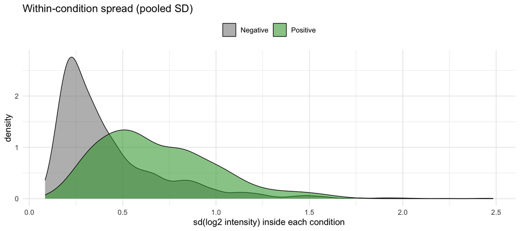

## Mean-variance relationship in the explicit protein-swap file

This plot shows the direct report-derived protein/run matrix. Each point is one protein. The x-axis is mean log2 intensity and the y-axis is pooled within-condition SD. It is the protein-swap analogue of the sample-swap mean-variance diagnostic.

Here the Positive trend being above the Negative trend is compatible with the protein-swap design: positives are the constructed regulated proteins. The important distinction is that the null class is not forced into a higher variance regime by mixing dilution levels inside each condition. This is why the protein-swap diagnostic is a better control for variance-moderated methods than the sample-swap diagnostic where H0 proteins are made artificially more variable than H1 proteins.

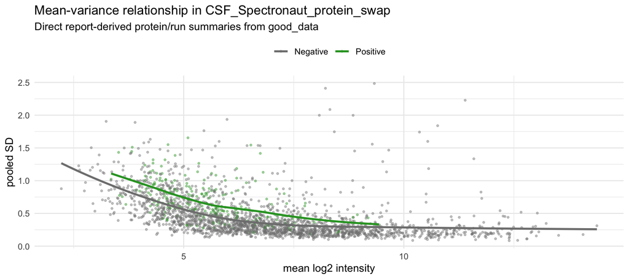